# FARMR!SK automatic report

The main pathways of disease entry are: **Vehicle visits to the farm** and **Animal transport**.

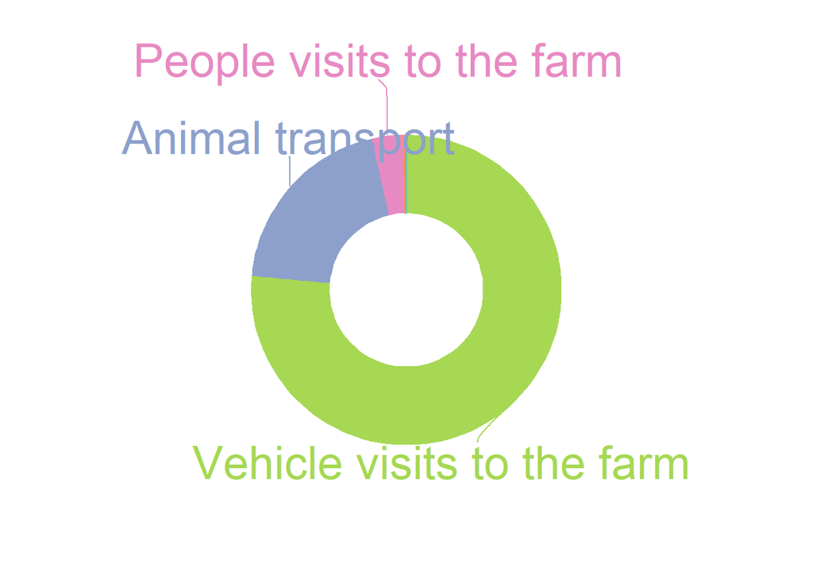

(a) IBR

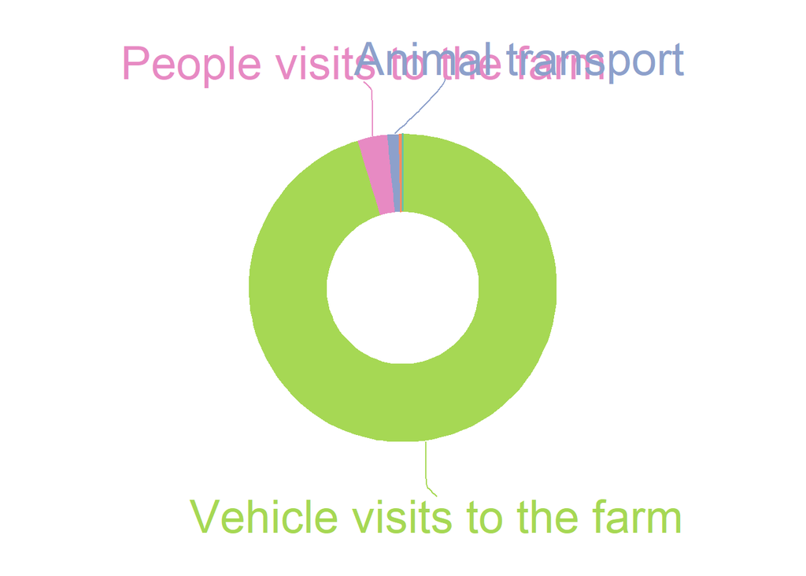

(b) BVD

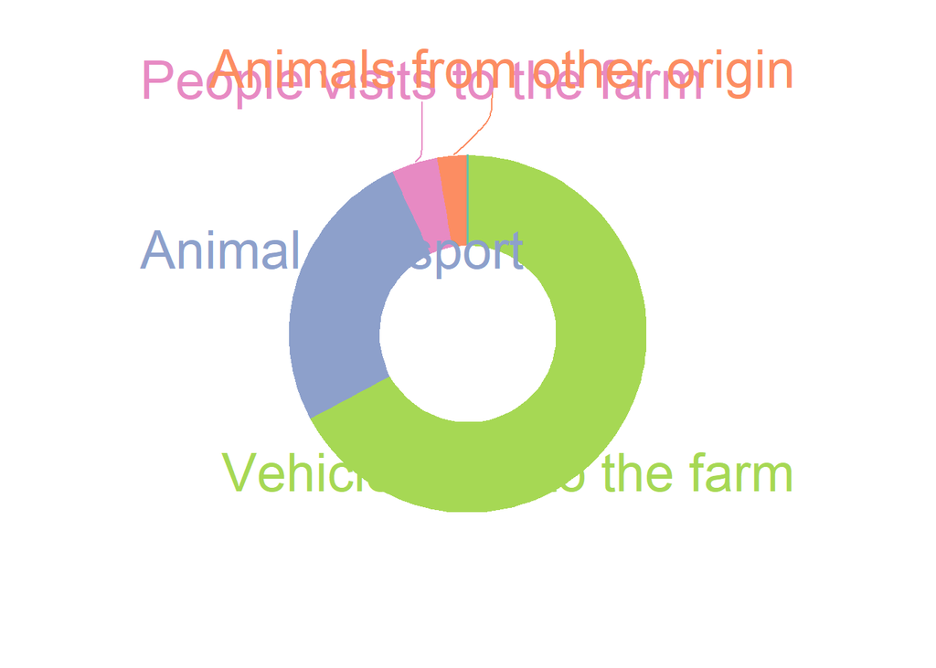

(c) TB

Figure 1.2: Risk of disease entry by pathway

## **Infectious Bovine Rhinotracheitis (IBR)**

### Current risk

Annual risk of IBR entry in the farm: **15%** (7.61-23%)

By pathway:

- Vehicle visits to the farm: **11.7%** (4.19-20.1%)
- Animal transport: **3.06%** (1.09-5.98%)
- People visits to the farm: **0.486%** (0.169-0.908%)
- Animals from other origin: **0.05%** (0.0341-0.0731%)
- Neigbouring farms: **0.00413%** (0.000189-0.0133%)

### Risk reduction of biosecurity measures

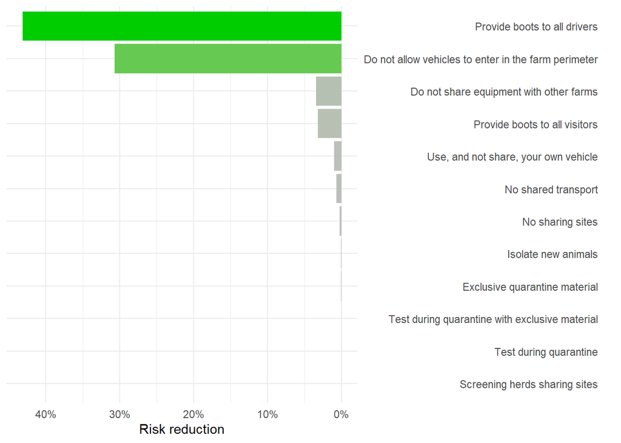

## **Bovine viral diarrhea (BVD)**

### Current risk

Annual risk of BVD entry in the farm: **21.3%** (7.54-36.3%)

By pathway:

- Vehicle visits to the farm: **20.5%** (6.53-35.5%)
- People visits to the farm: **0.673%** (0.347-1.17%)
- Animal transport: **0.257%** (0.109-0.477%)
- Animals from other origin: **0.0822%** (0.0282-0.164%)
- Neigbouring farms: **1.43e-10%** (5.77e-13-2.18e-09%)

### Risk reduction of biosecurity measures

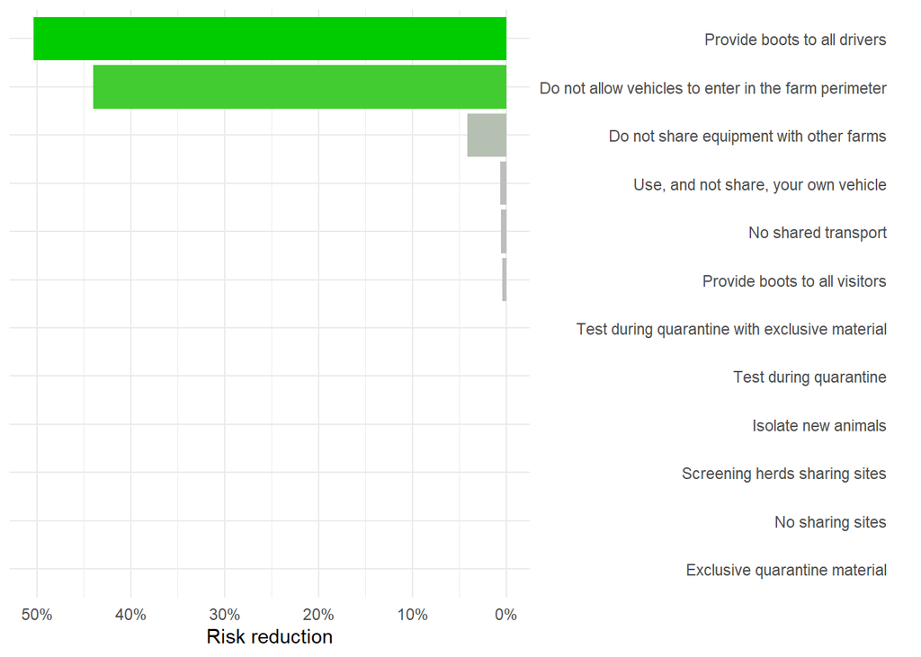

## **Bovine Tuberculosis (TB)**

### Current risk

Annual risk of TB entry in the farm: **0.0197%** (0.0049-0.0651%)

By pathway:

- Vehicle visits to the farm: **0.0117%** (0.000801-0.0567%)
- Animal transport: **0.0045%** (0.000597-0.0176%)
- People visits to the farm: **0.000724%** (0.000138-0.00483%)
- Animals from other origin: **0.000469%** (0.000282-0.000828%)
- Neigbouring farms: **5.12e-07%** (2.41e-10-1.63e-05%)

### Risk reduction of biosecurity measures

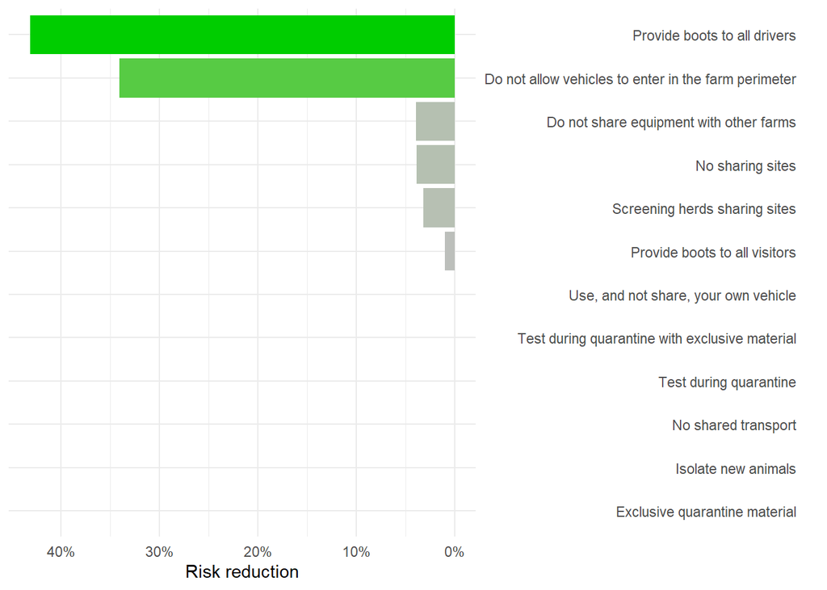

# 🐄 Description of the farm

## Farm information

**Location:** Cataluña, Spain

**Farm type:** Dairy cattle, NA

**Cattle cens:**

- 1 Calves ( <8 m)
- 100 Heifers (8 - 24 m)
- 200 Adult cows (>24 m)

**Other animals in the farm:**

- **Direct contact with cattle:**
- **No direct contact with cattle:**

**Neighbours**: 1 cattle farms within a 1-2km radious, no direct contact (IBR: 0.00413%, BVD: 1.43e-10%, TB: 5.12e-07%)

## Farm vehicles

| veh_id | Size | Shared | Cleaning |
| --- | --- | --- | --- |
| Remolcote amarillo (a) | 18m2 | Shared with 1 cattle farms | Each time it is used |

## Visits

### People entering the barn

| Visit | Type | Frequency | Boots | Equipment | Risk |
| --- | --- | --- | --- | --- | --- |
| Treballadors | Farm workers that own livestock or work on other farms | 60 | Never used in other farms | Always used in other farms, sometimes cleaned and disinfected | IBR: 0.339%, BVD: 0.0777%, TB: 0.00045% |
| Veterinari clinic | External veterinarians | 52 | Always used in other farms, unk cleaned and disinfected | Always used in other farms, always cleaned and disinfected | IBR: 0.0643%, BVD: 0.243%, TB: 8.14e-05% |
| Veterinari reproducció | External veterinarians | 52 | Always used in other farms, unk cleaned and disinfected | Always used in other farms, always cleaned and disinfected | IBR: 0.0615%, BVD: 0.244%, TB: 7.87e-05% |
| Podòleg | Other animal professionals (e.g. hoof trimmer) | 9 | Always used in other farms, always cleaned and disinfected | Always used in other farms, always cleaned and disinfected | IBR: 0.0146%, BVD: 0.056%, TB: 1.86e-05% |
| Veterinari sanejament | External veterinarians | 2 | Always used in other farms, unk cleaned and disinfected | Always used in other farms, always cleaned and disinfected | IBR: 0.00243%, BVD: 0.00907%, TB: 3.07e-06% |

### Vehicles entering the farm perimeter

| Visit | Type | Frequency | Driver | Risk |
| --- | --- | --- | --- | --- |
| Vedells engreix | Calf transport vehicle | 51 | Contacts farm animals, boots always used in other farms, never cleaned and disinfected | IBR: 11.4%, BVD: 20.4%, TB: 0.0115% |
| Llet | Milk collection vehicle | 1000 | - | IBR: 0.188%, BVD: 0.0337%, TB: 1.3e-05% |
| Escorxador vaques | Slaughterhouse vehicle | 24 | No contact with animals | IBR: 0.0497%, BVD: 0.00959%, TB: 2.89e-06% |
| Recría | Calf transport vehicle | 36 | No contact with animals | IBR: 0.0288%, BVD: 0.0613%, TB: 8.87e-07% |
| Concentrat i gra | Feed vehicle | 52 | - | IBR: 0.0128%, BVD: 0.00243%, TB: 7.84e-07% |
| Cadàvers | Rendering vehicle | 12 | - | IBR: 0.00423%, BVD: 0.000795%, TB: 2.37e-07% |

# 🚚 Movements

Animal movements in the last 12 months

| mov_id | When | Origin | Animals moved | Shared site | Vehicle used | Risk |
| --- | --- | --- | --- | --- | --- | --- |
| recria | 🔁 Recurrent round: 36 times/year, out for 390 days | Other farm/s: Barcelona | 5 Heifers (8 - 24 m) | No | Own Remolcote amarillo | IBR: 2.91%, BVD: 0.0096%, TB: 0.00424% |
| concurs_galicia | 🔁 One-off round: From 2024-04-01 to 2024-05-01 | Livestock fair: Galicia | 1 Heifers (8 - 24 m) | Shared with 50 animals from 10 farms NA | External (shared journey) | IBR: 0.133%, BVD: 0.242%, TB: 0.000184% |
| concurs_girona | 🔁 One-off round: From 2024-06-01 to 2024-06-03 | Livestock fair: Cataluña | 3 Heifers (8 - 24 m) | Shared with 30 animals from 10 farms NA | Own Remolcote amarillo | IBR: 0.0772%, BVD: 0.0756%, TB: 0.000423% |
| concurs_holanda | 🔁 One-off round: From 2024-05-01 to 2024-05-07 | Livestock fair: Austria | 2 Heifers (8 - 24 m) | Shared with 60 animals from 10 farms NA | External (shared journey) | IBR: 0.000464%, BVD: 0.000658%, TB: 0.000103% |

### Health status and tests in origin

| mov_id | Pathogen | Health status in origin | Test in origin |  |
| --- | --- | --- | --- | --- |
| recria | BVD | BVD- (Officially free) | - |  |
|  | IBR | IBR4 (Officially free) |  |  |
|  | TB | T3H (Long-term officially free) |  |  |
| concurs_galicia | BVD | Unknown |  | ELISA for antigen detection |
|  | IBR |  |  | ELISA for antibody detection |
|  | TB | T3H (Long-term officially free) | - |  |
| concurs_girona | BVD | Unknown | ELISA for antigen detection |  |
|  | IBR |  | ELISA for antibody detection |  |
|  | TB | T3H (Long-term officially free) | - |  |
| concurs_holanda | BVD | Unknown | ELISA for antigen detection |  |
|  | IBR |  | ELISA for antibody detection |  |
|  | TB | T3H (Long-term officially free) | - |  |

### Quarantine

#### Characteristics

*No quarantine*

# 🐗 Wildlife

**Wildlife:** negligible risk

- Outdoors grazing: No outdoors grazing (negligible risk)
- Pasture (trashumance): No pastures

### Farm water points

*No outdoors water points*

### Pasture water points

*No pasture water points*

# Comments

# Technical Annex

- Simulation date: 2025-11-17 13:16:24
- Script unification date: 2025-11-17 12:20:43
- Repository: https://github.com/NataliaCiria/biosecurity_model.git
- Last commit: 5b482c75a9928a4d9b1dd0f39f59ed7d93bb09e0
- Last commit date: 2025-11-16 17:22:55
- user_id:
- farm_id: bl2_v2_mod
- Risk timeframe: 360 days
- Calculate all summaries: FALSE
- Automatic what-if scenarios: TRUE
- Analyse model sensitivity: FALSE
- Farm biosecurity survey: bsg_cattle_v4_1_ciria 2014-10-03
- Movements surveys:
  - v4_1_ciria ( 4 ): concurs_galicia, concurs_girona, concurs_holanda, recria